# STAT 155: Introduction to Statistical Modeling

Macalester College, Fall 2025

- **Section 03**: M/W/F 09:40-10:40am, THTR 002
- **Section 04**: M/W/F 12:00-01:00pm, THTR 202

**Welcome to STAT 155!** Whether in life or research, we’re often interested in relationships between 2+ variables. For example, how is one’s commute time to class related to their distance from campus and mode of transportation? Or, how is voter participation related to a person’s age and political affiliation? **Statistical modeling** is the art and science of turning data into information about such relationships of interest.

Being able to **summarize**, **interpret**, and **communicate** about data are crucial for navigating today’s information landscape, and these are precisely the skills that we’ll build in this class. Throughout the semester, we’ll study the fundamental methods that statisticians use to extract knowledge from data, emphasizing statistical literacy & intuition, real data applications, and modern computing over memorizing facts and formulas.

# Learning Objectives

## Important technical concepts

Upon completion of this course, students should be able to:

- Build, use, and interpret **graphical and numerical summaries** of data.
- Given a research question: **identify** an appropriate model, use sample data to **fit** the model in RStudio (free!), **evaluate** the model’s quality, and **quantify** our uncertainty in the model’s coefficients and predictions.
- Use a sample model to make **predictions & inferences** about a population, using **prediction/confidence intervals & hypothesis tests**.
- **Interpret & communicate** an analysis in context & using appropriate notation, argumentation, & evidence.
- Describe potential **advantages, limitations, and ethical considerations** of a data set and statistical analysis.
- Identify **common pitfalls** in statistical analyses (e.g., spurious correlation vs. causal relationships, extrapolation, multicollinearity, multiple testing, practical vs. statistical significance).
- Accurately **describe methods and results** in a way that is scientifically sound and widely accessible.
- Work **productively and effectively** in a group setting.

## Important statistical skills

The following skills are essential both within and beyond Statistics, and demonstrably improve your own learning and the learning of those around you:

- Move beyond a “homework only” study approach. Develop a deeper understanding of the material through **continued review, reflection, and practice**.
- Think **creatively, and build confidence**, applying course concepts in open-ended, novel settings.
- Be comfortable working through **challenges and mistakes**.
- Contribute to a **welcoming and engaged learning environment**.
- Work effectively in a **group setting**.

# Instructor/Preceptor Team

## About your professor

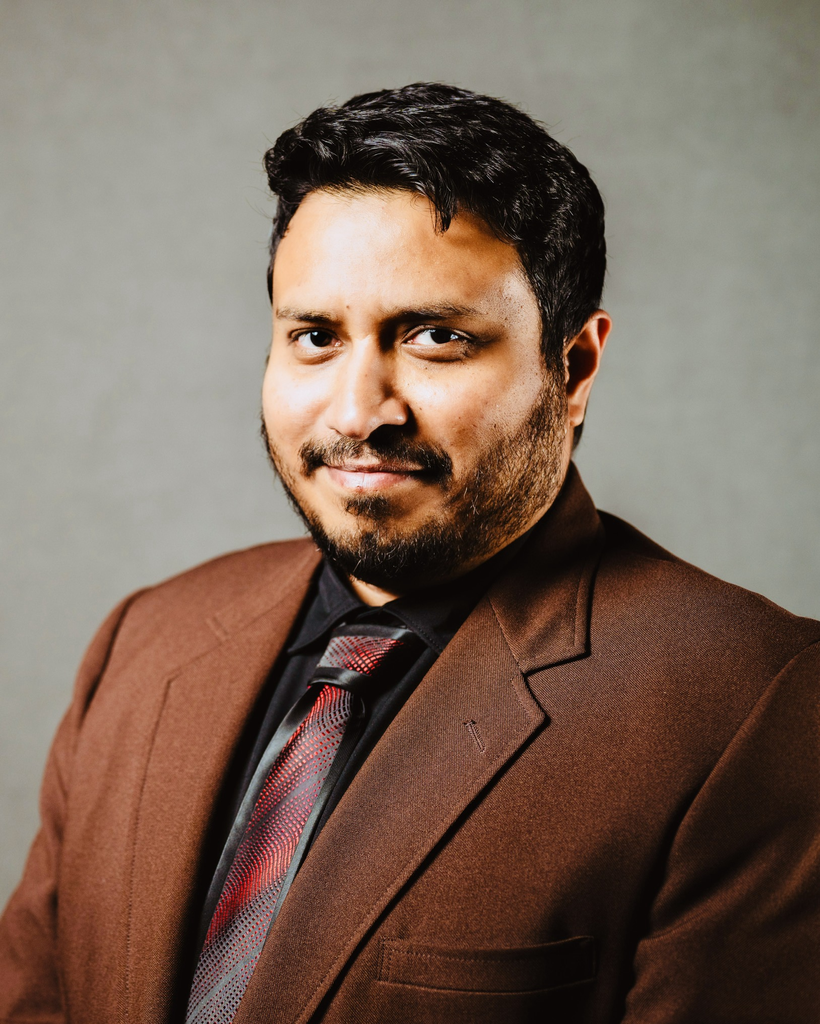

**Md Mutasim Billah, PhD**

**Pronunciation:** [listen here](https://namedrop.io/mdmutasimbillah)

**Office:** Olin-Rice 234

**Email:** mbillah@macalester.edu

**Notes from “your professor”**

Greetings! You can call me *Bill* or *Professor Billah* & I use he/him pronouns. Back when I was an undergrad student, I didn’t have the best experience in Intro Stat—those courses often emphasized formulas over real understanding. That experience has shaped my teaching—I concentrate on illustrating how statistical theories connect and can be applied in the real world. I’m excited to teach STAT 155 and to create a more meaningful experience—one that helps all students feel confident applying it beyond the classroom. My methodological research lies at the intersection of statistical genetics, biostatistics, and genomics. My current research interests include developing novel statistical methods and computationally efficient bioinformatics tools, leveraging modern machine- and deep-learning approaches analyze high-dimensional next-generation sequencing and multi-omics data to identify genes and regulatory mechanisms underlying complex diseases. Outside of my academic work, I enjoy spending time outdoors with family and friends or cooking variety of foods. If you can’t find me anywhere, I might be busy playing soccer or exploring new worlds on my PS5 Pro!

**Drop-in (office) hours:**

- **Location:** My office (OLRI 234)
- **Times:** M/W: 01:30-02:30 pm.
- **24/7 by Appointment:** I’m also happy to meet one-on-one if my normal drop-in hours don’t work for you. Shoot me an email and we can arrange it either in-person or over [zoom](https://macalester.zoom.us/j/99762878654?pwd=gt7VvSNT0ubKsV2icMV3z8J0GyHKMy.1), password: 123456.

## About your preceptors

We have several wonderful STAT 155 preceptors this semester! Their role is to help students with content questions, assist in the navigation of available resources, advise on studying approaches, and assist with concepts, tools, and skills. Students are accountable for their own learning; as such, preceptors are not allowed to share answers to assignments (unless specifically directed by the instructor), they are not expected to immediately know the right approach to an exercise, and they do not provide assistance outside of office hours.

In hiring preceptors, we prioritize and emphasize kindness and respect. I expect the same of students in their interactions with the preceptors. Please utilize and respect their experience and commitment to supporting you in this course. Please check out some [additional guidelines and expectations](https://docs.google.com/document/d/1USu-3R1NsGDVm0yU0HTzHuTpzCD3onBjNI5n8w9VBik/edit?tab=t.0) on how to interact with preceptors.

# Topics and Tentative Schedule

[output not shown]

# Course resources

## Textbook & Online Course Manual

There is no required textbook for this course. Throughout the course, readings may be assigned from these [notes](https://mac-stat.github.io/Stat155Notes/), or other sources.

The online course manual includes all in-class activities (with solutions) and a daily Schedule. All links and materials needed will be provided on the schedule tab of this website.

## Moodle

[Moodle](https://moodle.macalester.edu/) includes general resources, a broad course calendar, submission links, feedback, and a forum for student questions.

## Statistical software

We will use the (completely free and open source) R programming language extensively throughout this course. RStudio (an interface for R) will facilitate our use of R. You may use RStudio in one of two ways:

1. Desktop version: Download for Windows or Mac at https://posit.co/downloads/. Note: You first need to download and install R on your computer in order to use the desktop version of RStudio
2. Online: Go to https://rstudio.macalester.edu, and log in with your full Mac email address and your usual Mac password to get access. (Note that this is a shared resource across MSCS, and you may experience performance issues due to high traffic, server outages, etc.)

More detailed instructions on downloading, installing, and getting started with R, and RStudio are available on the Tech Setup tab.

## Office hours (OH)

Across the instructor and preceptors, there are several office hours each week. Names, times, and locations are on the Moodle course calendar. **IMPORTANT**: Always check the calendar before attending OH.

# Communication & Thriving

## Asking questions/communicating

### Office Hours

OH are a great place to chat about the course, career planning, life,… Please visit us!!

- OH times & locations are on the Moodle course calendar.
- OH are oriented around group discussion. They are not first come, first served appointments.
- Since it’s not an effective way to deepen your learning, OH are not a place to sit and do assignments with me or preceptors. It’s an opportunity to discuss concepts & specific questions.

### Moodle Forum

This forum is where we’ll communicate outside class. Students can post and answer comments / questions there. This is an informal way to converse, ask questions, share info, & connect. Do not rely on receiving responses outside weekdays between 9am & 5pm.

## What to do when you have a question for me?

- If it’s non-private (e.g. about policies, homework, etc), you must post it on the public Moodle forum.
- If it’s personal (e.g. about an absence), email me.
- It’s good, professional practice to check whether your question is already answered in the provided resources. For example:
  - **Info** (what to do if you miss class): syllabus
  - **Due dates**: course calendar at the top of Moodle + course schedule in the online manual
  - **Quiz dates**: syllabus + course calendar at the top of Moodle + course schedule in the online manual
  - **Homework policies & grading**: [homework policies & grading](https://docs.google.com/document/d/1gffiL-OKMrHSqgNijI2pnjliyzNWg8vIIfoP2MY_DSA/edit?tab=t.0#heading=h.y44zqzjp7zgk) doc
  - **Finals week**: syllabus + course calendar at the top of Moodle + course schedule in the online manual

## Thriving in STAT 155

**🗓️ Plan Ahead**

You should plan to spend ~10-12 hours on any 4-credit course, including class time.[^1] Stay up-to-date on the course calendar and carve out time for studying & doing homework.

**✅ Do the Things**

At minimum, thriving in this course requires the completion of some concrete tasks. Complete all assignments, regularly attend & engage in class, complete in-class activities (which might mean completing work outside of class), and check the activity solutions.

**🏗️ Build a Foundation**

If your main focus is on checking off some boxes, you won’t get much out of this course (or college in general). Deeper, enduring learning requires more. Carve out time to rewrite, reflect upon, & review your notes. Summarize concepts in your own words.

**🎉 Engage, Ask Questions, Have Fun**

Actively participate in the class & take ownership of your learning. PLEASE: Don’t be afraid to ask for help, make mistakes, and ask questions! These skills are critical to your well-being & learning. Finally, have some fun, be curious, and reflect upon what surprises you about the material and yourself

# Course Policies

## Flexibility

I provide transparent accommodations to all students. It helps reduce stress and the “hidden curriculum” (not everybody feels comfortable asking for flexibility).

- **Missed Class**: It’s okay to miss class in the case of an emergency.
- **Practice Problems (PP)**: limited extensions and limited mistakes without penalty. Please *carefully* go through all the sections from [STAT 155 PP Policies & Grading](https://docs.google.com/document/d/1gffiL-OKMrHSqgNijI2pnjliyzNWg8vIIfoP2MY_DSA/edit?tab=t.0#heading=h.b4wcvjckjps) doc.
- **Checkpoints**: your lowest scores are essentially dropped and there are limited mistakes without penalty.
- **Quizzes**: limited revisions. Additional flexibility will be provided in rare extenuating circumstances, upon discussion. Exceptions must be discussed with me (not assumed) early on (not after the fact).

**🤝 **PLEASE REACH OUT WHEN YOU NEED HELP.**

## Absences

It’s okay to miss the occasional class. Except in rare extenuating circumstances (which must be discussed in advance): - 3 or fewer absences will not impact your grade - 4-6 absences will impact your grade (see *Calculating Final Grades* section) - you cannot pass the course if you accrue 7+ absences (more than 25% of class sessions)

**What to Do If You Miss Class**

1. 📧 **Send me a quick email.** You do not need to share a reason for your absence, especially if it’s personal. It’s just a simple courtesy & keeps communication lines open.
2. 📅 **Check the Course Schedule** in the online manual for what is happening in class that day.
3. 📝 **Complete the in-class activity on your own** & check the solutions posted in the online manual.
4. 💬 **Ask any follow-up questions** on the Moodle forum or in office hours (OH).

## Artificial Intelligence (AI)

Using AI tools is an emerging skill. You may use AI (ChatGPT, Gemini, Grok, etc), with some caveats & limitations:

- AI is often wrong, thus is not a good resource on topics for which you don’t yet have expertise. Relatedly, though AI can be helpful with parts of a statistical analysis (eg: getting unstuck on code, checking grammar), you have to guide that process (eg: what questions are we trying to answer? what’s a reasonable approach?).
- Work on an exercise for at least 30 minutes before even thinking about AI. You will learn very little if you overly rely on AI, hence be unprepared for other interactions with the material (eg: in-class discussions, quizzes, future courses that build upon 155, etc). Learning comes from you doing the puzzling, not from you producing a correct answer.
- Whether or not you use AI, you must be able to defend/explain any code/discussion you hand in. You cannot simply use AI to bypass your own learning.
- You may not use AI to generate entire arguments or discussions. Putting code and discussions into your own words is critical for your own deeper learning, independent thinking, and creativity. (For example, imagine how little you’d learn in a language course if you simply used AI to translate all text for you!!)
- Any use of AI must be cited, just like any other resource.

## Community & Academic Integrity

MSCS strives to provide a learning environment that is equitable, inclusive, welcoming, mutually respectful, and free of discrimination. You’re expected to follow the [MSCS Community Guidelines](https://docs.google.com/document/u/3/d/e/2PACX-1vSlLLWmyOf8WKGDKJ_qypgA_kQI1dNFGEKH0mtFoqfAUARZN7ypVCgivnmPjccks9jJzW1rgEzt7QMI/pub). You’re also required to be familiar with & follow the college’s [academic integrity](https://www.macalester.edu/academicprograms/academicpolicies/academicintegrity/) & other [academic policies](https://www.macalester.edu/academic-programs/academicpolicies/). In addition to the examples listed there, academic violations in this course include but are not limited to the following:

- Using **any** materials from **any** past STAT 155 course, at Mac or elsewhere. Relatedly, you should not provide any materials to any future 155 students.
- Gaining access to, using, or distributing solution sets.
- Passing off others’ work as your own. You must be able to defend / explain all work you hand in.
- Using AI without citation, to generate entire discussions / code blocks, or without being able to defend the results. Policy violations will result in a score of 0 on the work & be reported to the Asst. Dean of Academic Programs & Advising.

# The 6 Core Components (EC3PQ!)

## (1) Engagement

Engagement is important to your own learning & to fostering a supportive learning community.

**📌 Expectations**

- **Do not miss more than 3 in-person class sessions.** (4–6 absences will lower your grade. 7+ absences will result in a D/NC.)
- **When attending class:**
  - Be on time & don’t leave early
  - Do not use your phone (phones must be put away when you enter the course, even if class hasn’t started)
  - [Do not use your laptop for anything other than taking notes](https://www.sciencedirect.com/science/article/pii/S0360131512002254) (e.g., no videos, no email, no messaging apps, etc.)
  - Be actively present (e.g., don’t work alone, don’t work on other courses, etc.)
- **Outside class:**
  - Check your email for announcements (sent via Moodle) and stay updated on the Moodle forum
  - When you have questions, or just want to chat, please stop by OH!

**NOTE**: To share clear & consistent information, any deviations from these expectations will be recorded in the “In-class engagement & collaboration” activity on Moodle.

## (2) Colloboration

Collaboration improves higher-level thinking, confidence, communication, community, & more. You will work in groups in and outside class. These groups will occasionally switch & will sometimes be assigned.

**🤝 Expectations**

- Follow the [MSCS Community Guidelines](https://docs.google.com/document/u/3/d/e/2PACX-1vSlLLWmyOf8WKGDKJ_qypgA_kQI1dNFGEKH0mtFoqfAUARZN7ypVCgivnmPjccks9jJzW1rgEzt7QMI/pub)
- In group settings, both in and outside class, you:
  - Use your group members’ correct names and pronouns
  - Actively contribute to discussions
  - Actively include all other group members in discussion
  - Create a space where others feel comfortable making mistakes & sharing their ideas
  - Effectively communicate with your group about meeting times, etc.

**NOTE**: To share clear & consistent information, any deviations from these expectations during in-class collaborations will be recorded in the “In-class engagement & collaboration” activity on Moodle.

## (3) Preparation (Checkpoints)

Roughly half of our class sessions will require some prep work. Before class you will watch videos which introduce new concepts, then take a low-stakes checkpoint quiz (CP). This will help us prepare for class, build a common foundation, & maximize our time together – just how readings & reading reflections might be used in another class!

**📊 Expectations**

Pass 13+ of the 16 CPs (≈80%); **OR** earn at least 80% of total points across all CPs.

**📜 Policies**

- You will make mistakes and that’s ok!
  - You can reattempt most CP questions with a 33% penalty for each incorrect response.  
    *Exceptions*: open-ended questions or multiple choice questions with only 2 options (TRUE/FALSE).
  - CPs are graded pass/fail. To pass, you must earn at least 80% of the points.
  - The goal is to pass 13+ CPs. Thus you may miss or not pass 3 CPs without it impacting your grade.
- CPs are due **10 minutes before class** on the assigned date. **There are no extensions for CPs**, as they are important *preparation* for the relevant class session.

## (4) Practice

In 8 practice problem sets (PP), you will practice and explore the course material in more depth. The following flexibility is built in to help reduce stress and to facilitate deeper learning. Detailed directions and policies are [here](https://docs.google.com/document/d/1gffiL-OKMrHSqgNijI2pnjliyzNWg8vIIfoP2MY_DSA/edit?tab=t.0#heading=h.y44zqzjp7zgk).

- **Grading**: PP grades will be based on Exercises & Presentation. You can make some mistakes without it chipping away at your score (e.g. you will earn 5/5 points on an exercise if it’s at least 90% correct & complete).
- **Dropped score**: *IF* you submit and demonstrate clear effort on all 8 PPs, your lowest PP score will be dropped from your final grade.
- **Extensions**: Limited extensions will be provided.

## (5) Project (Independence & Application)

More details will be provided later in the semester. Here are some basics:

- We’ll start working on projects in ~week 6, with the majority of the work happening later in the semester.
- The projects are *collaborative*. You will be working in groups. Though you will work in assigned groups at various points throughout the semester, you will pick your own group for the project. This is something to think about as you meet other students in class and learn about common interests.
- Project grades will be based upon a final group written report (no oral presentation), multiple group and individual checkpoints, and individual contributions to the project (thus it’s possible for different group members to earn different grades).

## (6) Quizzes (Content Expertise)

Your course engagement, collaboration, preparation, practice, and application will support your deeper understanding of the course material. This will be assessed through three in-person quizzes. You must schedule all travel and other commitments around them — there will not be any alternative quiz times.

**📜 Quiz Policies**

- **All quizzes will have the following format:**
  - Taken individually, using pen/pencil & paper
  - You will not need to write code or use a calculator, but you will need to read & interpret R output
  - Closed notes, but you may use a 3x5 index card with writing on both sides. These can be handwritten or typed, but you may not include screenshots or share note cards. Making your own card is important to the review process.
- **Quizzes 2 & 3 will be cumulative.** This is unavoidable as the material builds upon itself.
- **Quiz corrections:**  
  You can earn up to 50% of missed points back on Quizzes 1 & 2 if you:
  1. Write a reflection of how you prepared for the quiz and where you felt strongest or more uncertain in your understanding before taking the quiz; and
  2. Submit your quiz corrections along with your reflection to the instructor, no later than one week after quizzes have been handed back.  
     **Note**: Quiz 3 corrections are not allowed due to time constraints at the end of the semester.

# Calculating Final Grades

## Grading system

The grading system in this course is designed to help you achieve the learning objectives while allowing space to make and learn from mistakes along the way. Your final course grade will consist of three, evenly-weighted components (Quizzes, Practice Problems, and the Project), modified by your progress toward the Engagement, Collaboration, and Preparation (Checkpoint) goals:

### Course Percentage

$\tfrac{1}{3}$ Practice Problems +  
$\tfrac{1}{3}$ Quiz total +  
$\tfrac{1}{3}$ Project

| Grade | Course percentage |
| --- | --- |
| A | > 90% |
| A- | 87–90% |
| B+ | 84–87% |
| B | 81–84% |
| B- | 78–81% |
| C+ | 75–78% |
| C | 72–75% |
| C- | 69–72% |
| D/NC | < 69% **or 7+ absences** |

### Grade Modifiers

Engagement (including attendance) +  
Collaboration +  
Preparation (checkpoints)

| Modifier | Scenario |
| --- | --- |
| none (e.g. A → A) | Meets expectations in all 3 areas (Engagement, Collaboration, Preparation) |
| ⅓ lower grade (e.g. A → A-) | Demonstrates strong progress (e.g., 4 absences or 70% checkpoint total, or…) |
| 1 lower grade (e.g. A → B) | Demonstrates moderate progress (e.g., 5–6 absences or 50% checkpoint total, or…) |
| >1 lower grade | Demonstrates little progress toward expectations in all 3 areas |
| Drop to D/NC | Has 7+ absences |

**NOTE:** The table presents general scenarios. Please reach out if you want to discuss progress in Engagement, Collaboration, and/or Preparation.

**📊 Grading Cavities**

- The goal of sharing this specific information is to provide transparency around final grades, hence clear goals to work toward. That said, assigning grades is much more nuanced than any grading rubric / framework might suggest (for good reasons). What’s shared here is a **worst case scenario** – it represents the lowest a grade might be if you meet the corresponding goals.
- Moodle does NOT correctly weight your grades, thus should not be used alone to monitor your progress.

# Other policies

## What to Do If You Miss Class

If you do miss class, I expect you to complete any in-class activities on your own. Check the solutions in the online manual and come to office hours with any follow-up questions.

## Late work on Practice Problems (PPs)

Throughout the semester, you may use up to three, three-day extensions. These three extensions can be used on **Practice Problems** only, not **quizzes**. The purpose of deadlines (and extensions) are to keep you accountable for your own learning, to keep you on track with the pace of the course (which builds upon itself throughout the semester), and to provide preceptors and myself with the ability to provide you with timely feedback on assignments. Since the Problem Sets are due roughly every two weeks, you must begin working on them early if you want to succeed.

Extensions can be used automatically, without letting me know in advance. The Moodle dropboxes for assignments will close exactly 3 days after the original deadline (i.e. Mondays at 11:59pm), and I will not accept work submitted after that point unless there are extenuating circumstances that you have communicated with me about ahead of the original deadline. If you email me a completed assignment after a 3-day extension is up, I may have the preceptors provide you with feedback, but you will not receive credit for the assignment (equivalent to “Needs Improvement” on every question of the relevant assignment).

I expect you to keep track of how many extensions you’ve used. I will do my best to email you a reminder if you have used all three of your extensions and have none remaining.

If you have run out of extensions and/or an extenuating circumstance occurs that impacts your ability to submit assignments on time, please email me to discuss the situation. **I am happy to be flexible as long as you communicate!**

## Religious Observance

Students may wish to take part in religious observances that occur during the semester. If you have a religious observance/practice that conflicts with your participation in the course, please contact me before the end of the second week of the semester to discuss appropriate accommodations.

In an effort to respect religious diversity, I request that students who plan to observe a religious holiday during scheduled class meetings/class requirements talk to me about reasonable consideration by the end of the second week of the course.

## Well-being

I want you to succeed. Both here at Macalester and beyond. To help make this happen, I am committed to the following.

**Respect:** Everyone comes from a different path through life, and it is our moral duty as human beings to listen to each other without judgment and to respect one another. I have no tolerance for discrimination of any kind, in and out of the classroom. If you are seeking campus resources regarding discrimination, the [Department of Multicultural Life](https://www.macalester.edu/multiculturallife/) and the [Center for Religious and Spiritual Life](https://www.macalester.edu/religiouslife/) are wonderful resources. We will also respect the [MSCS Community Guidelines](https://docs.google.com/document/d/e/2PACX-1vSlLLWmyOf8WKGDKJ_qypgA_kQI1dNFGEKH0mtFoqfAUARZN7ypVCgivnmPjccks9jJzW1rgEzt7QMI/pub).

**Sensitive Topics:** Applications in this course span issues in science, policy, and society. As such, we may sometimes address sensitive topics. I will try to announce in class if an assignment or activity involves a potentially sensitive topic. If you have reservations about a particular topic, please come talk to me to discuss possible options.

**Accommodations:** If you need accommodations for any reason, please contact [Disability Services](https://www.macalester.edu/studentaffairs/disabilityservices/accommodations/) to discuss your needs, and speak with me as soon as possible afterwards so that we can discuss your accommodation plan. If you already have official accommodations, please discuss these with me within the first week of class so that you get off to a great start. Contact me if you have other special circumstances. I will find resources for you.

**Title IX:** You deserve a community free from discrimination, sexual harassment, hostility, sexual assault, domestic violence, dating violence, and stalking. If you or anyone you know has experienced harassment or discrimination, know that you are not alone. Macalester provides staff and resources to help you find support. **Please be aware that as a faculty member, it is my responsibility to report disclosure about sexual harassment, sexual misconduct, relationship violence, and stalking to the Title IX Office.** The purpose of this report is to ensure that anyone experiencing harm receives the resources and support they need. I will keep this information private, and it will not be shared beyond this required report.

You may also contact Macalester’s Title IX Coordinator directly (phone: 651-696-6258; e-mail: titleixcordinator@macalester.edu); they will provide you with supportive measures, resources, and referrals. Additional information about how to file a report (including anonymously) is available on the [Title IX website](https://www.macalester.edu/titleix/).

**General Health and Well-being:** I care that you prioritize your well-being in this semester and beyond. Investing time into taking care of yourself will have profound impacts on all aspects of your life. Remember that beyond being a student, you are a human being carrying your own experiences, thoughts, emotions, and identities. It is important to acknowledge any stressors you may be facing, which can be mental, emotional, physical, cultural, financial, etc., and how they can have an impact on you. I encourage you to remember that you have a body with needs. In the classroom, eat when you are hungry, drink water, use the restroom, and step out if you are upset and need some air. Please do what is necessary so long as it does not impede your or others’ ability to be mentally and emotionally present in the course. Outside of the classroom, sleeping well, moving your body, and connecting with others can be strategies can help nourish you. If you are having difficulties maintaining your well-being, please don’t hesitate to contact me and/or find support from physical and mental health resources [here](https://docs.google.com/document/d/1lz-ii5yze_OSkQJqz_7pap7fRjG81LJh0_saBniP-zg/edit), [here](https://docs.google.com/document/d/1iC-ykD8QJ-w2BVO1Gb0AobD-00Zq_8mznWR5C2mNiF0/edit?usp=sharing), and [here](https://www.macalester.edu/current-students/).

# Note

This syllabus is subject to change at any time! Announcements of changes will be made in class or via email.

## Footnotes

[^1]: [Macalester Academic Advising – High School Preparation](https://www.macalester.edu/academic-programs/academicadvising/students/highschool/)